# Combining repulsion and nudging

The next plot shows the effect of nudging with the original positions as black dots and the nudged positions as red dots.

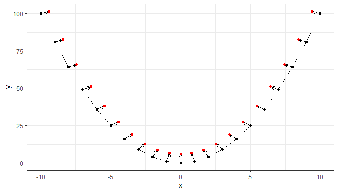

```r
ggplot(df, aes(x, y)) +
  geom_point() +
  geom_line(linetype = "dotted") +
  geom_point_s(position = position_nudge_line(x = 0.6, y = 6),
               colour = "red")
```

Negative values passed as arguments to `x` and `y` correspond to labels below and outside the curve.

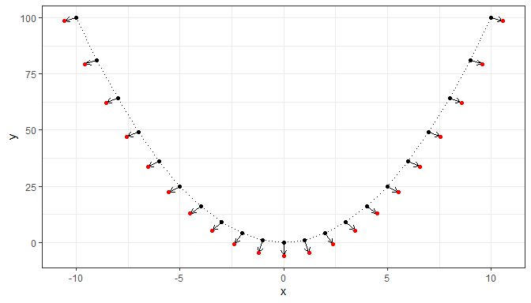

```r
ggplot(df, aes(x, y)) +
  geom_point() +
  geom_line(linetype = "dotted") +
  geom_point_s(position = position_nudge_line(x = -0.6, y = -6),
               colour = "red")
```

When the observations include random variation along *y*, it is important that the smoother used for the line added to a plot and that passed to `position_nudge_line()` are similar. By default `stat_smooth()` uses `"loess"` and `position_nudge_line()` with method `"spline"`, `smooth.sline()`, which are a good enough match.

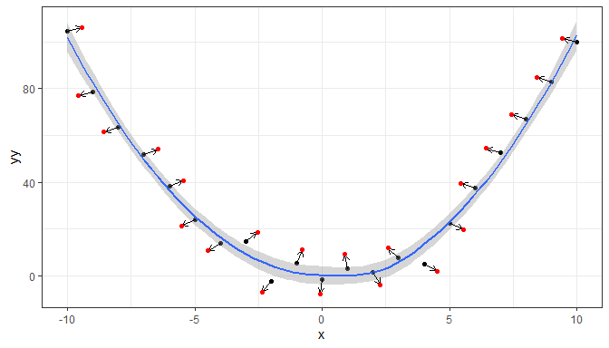

```r
ggplot(df, aes(x, yy)) +
  geom_point() +
  stat_smooth(method = "loess", formula = y ~ x) +
  geom_point_s(position = position_nudge_line(x = 0.6, y = 6,
                                              direction = "split"),
               colour = "red")
```

We can use other geometries, or rather we need to use a repulsive geometry when the label text is long or the labels are crowded near the line. Combining repulsion and computed nudging is effective.

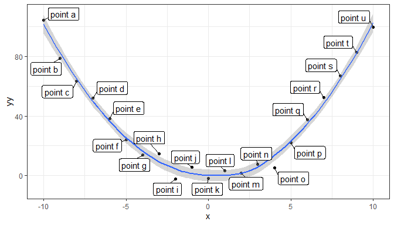

```r
ggplot(df, aes(x, yy)) +
  geom_point() +
  stat_smooth(method = "loess", formula = y ~ x) +
  geom_label_repel(aes(y = yy, label = paste("point", l)),
                   position = position_nudge_line(x = 0.6,
                                                  y = 8,
                                                  direction = "split"),
                   box.padding = 0.3,
                   min.segment.length = 0)
```

We can see by comparing the plot above with that below, that combining nudging away from a line with repulsion results in a more pleasant positioning of the data labels.

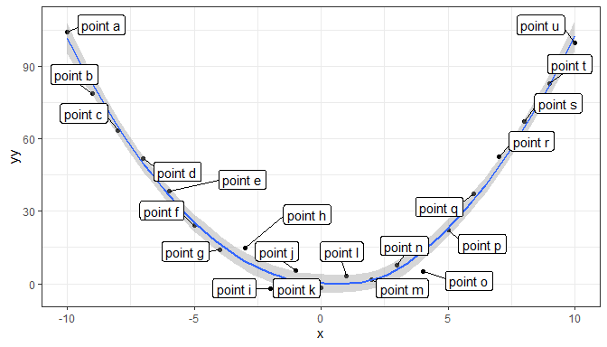

```r
ggplot(df, aes(x, yy)) +
  geom_point() +
  stat_smooth(method = "loess", formula = y ~ x) +
  geom_label_repel(aes(y = yy, label = paste("point", l)),
                  box.padding = 0.5,
                  min.segment.length = 0)
```

Nudging alone, as shown next, results in overlaps and clipping.

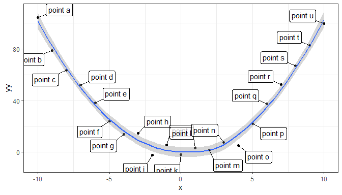

```r
ggplot(df, aes(x, yy)) +
  geom_point() +
  stat_smooth(method = "loess", formula = y ~ x) +
  geom_label_s(aes(y = yy, label = paste("point", l)),
               position = position_nudge_line(x = 0.6,
                                              y = 8,
                                              direction = "split"),
               box.padding = 0,
               min.segment.length = 0)
```

While `box.padding` in `geom_text_repel()` controls the separation among data labels as well as between data labels and points, in `geom_label_s()` it controls only the distance between the end of the segment and the data label.

When fitting a polynomial, `"lm"` should be the argument passed to `method` and a model formula preferably based on `poly()`, setting `raw = TRUE`, as argument to `formula`.

*Currently no other methods are implemented in* `position_nudge_line()`.

In the case of data labels that are small, a single character in the next example, we also benefit from nudging if they are near a fitted line. Nudging plus repulsion, shown next, will be compared to alternatives. In this case we assume no linking segments are desired as there is enough space for the data labels to remain near the observations.

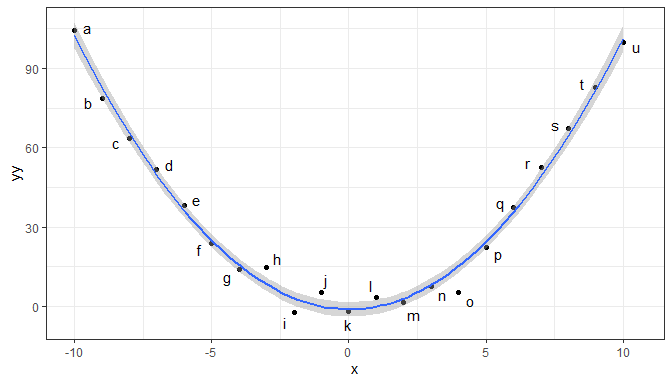

```r
ggplot(df, aes(x, yy)) +
  geom_point() +
  stat_smooth(method = "lm",
              formula = y ~ poly(x, 2, raw = TRUE)) +
  geom_text_repel(aes(y = yy, label = l),
                  position = position_nudge_line(method = "lm",
                                                 formula = y ~ poly(x, 2, raw = TRUE),
                                                 x = 0.5,
                                                 y = 5,
                                                 direction = "split"),
                  box.padding = 0.25,
                  min.segment.length = Inf)
```

Using nudging alone there is little difference, but there is always the posibility of overlaps, so using nudging plus repulsion as above is safer.

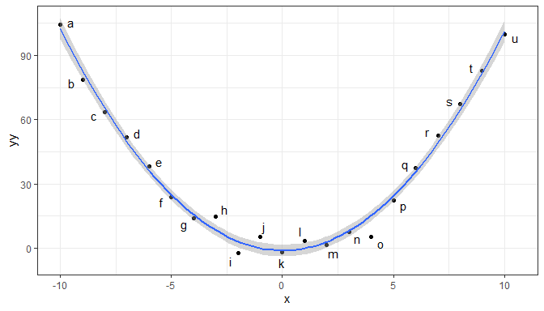

```r
ggplot(df, aes(x, yy)) +
  geom_point() +
  stat_smooth(method = "lm",
              formula = y ~ poly(x, 2, raw = TRUE)) +
  geom_text(aes(y = yy, label = l),
            position = position_nudge_line(method = "lm",
                                           formula = y ~ poly(x, 2, raw = TRUE),
                                           x = 0.5,
                                           y = 5,
                                           direction = "split"))
```

Repulsion without nudging as shown below is unsatisfactory in this case, i.e., adding nudging displaces the data labels in the desired direction. Compare the plot below using no nudging with the one above.

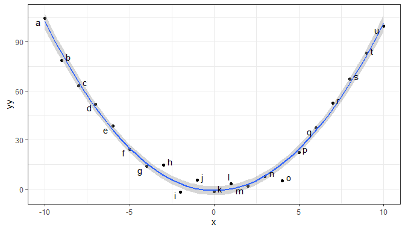

```r
ggplot(df, aes(x, yy)) +
  geom_point() +
  stat_smooth(method = "lm",
              formula = y ~ poly(x, 2, raw = TRUE)) +
  geom_text_repel(aes(y = yy, label = l),
                  box.padding = 0.25,
                  min.segment.length = Inf)
```

## Combined position functions

Using `position_stacknudge()` together `geom_label_repel()` makes it possible to use repulsion for labeling sections of stacked column plots.

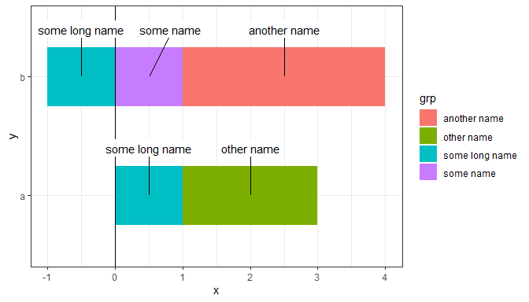

```r
df <- tibble::tribble(
  ~y, ~x, ~grp,
  "a", 1,  "some long name",
  "a", 2,  "other name",
  "b", 1,  "some name",
  "b", 3,  "another name",
  "b", -1, "some long name"
)

ggplot(data = df, aes(x, y, group = grp)) +
  geom_col(aes(fill = grp), width=0.5) +
  geom_vline(xintercept = 0) +
  geom_label_repel(aes(label = grp),
                   position = position_stacknudge(vjust = 0.5, y = 0.4),
                   label.size = NA)
```

## Acknowledgements

I warmly thank Kamil Slowikowski for agreeing to make changes in ‘ggrepel’ that make the use of ‘ggrepel’ together with ‘ggpp’ possible and smooth. This document shows some use examples, but surely new ones will be found by users of R and ‘ggplot2’.